# ALY 6015: Intermediate Analytics

## Week 5 Project : Data Mining Applications

## Classification Analysis

### Data Introduction

Graduate Admissions dataset consists of 9 columns with 400 samples in total. The features of this dataset can be found here:

- GRE Scores (290 to 340)
- TOEFL Scores (92 to 120)
- University Rating (1 to 5)
- Statement of Purpose Rating(1 to 5) (SOP)
- Letter of Recommendation Strength (1 to 5) (LOR)
- Undergraduate CGPA (6.8 to 9.92)
- Research Experience (0 or 1)
- Chance of Admit (0.34 to 0.97)

My aim and purpose for this dataset is to predict whether a student will get admitted to a Master's degree given the features of the dataset.

The full dataset can be found at https://www.kaggle.com/mohansacharya/graduate-admissions.

### Importing Libraries and Data

```python
import pandas as pd
import seaborn as sns
import matplotlib.pyplot as plt
import numpy as np
import sys
import os

df = pd.read_csv(r"C:\Users\pltru\Google Drive\Masters\Graduate Admissions Project\Admission_Predict.csv", sep = ",")
```

### Descriptive Analytics

```python
df.info()
df=df.rename(columns = {'Chance of Admit ':'Chance of Admit'})
print(df.corr())
ds_df = pd.DataFrame(df.describe())
print(ds_df)
print(df.head())
```

```
<class 'pandas.core.frame.DataFrame'>
RangeIndex: 400 entries, 0 to 399
Data columns (total 9 columns):
Serial No.           400 non-null int64
GRE Score            400 non-null int64
TOEFL Score          400 non-null int64
University Rating    400 non-null int64
SOP                  400 non-null float64
LOR                  400 non-null float64
CGPA                 400 non-null float64
Research             400 non-null int64
Chance of Admit      400 non-null float64
dtypes: float64(4), int64(5)
memory usage: 28.2 KB
                   Serial No.  GRE Score  TOEFL Score  University Rating  \
Serial No.           1.000000  -0.097526    -0.147932          -0.169948
GRE Score           -0.097526   1.000000     0.835977           0.668976
TOEFL Score         -0.147932   0.835977     1.000000           0.695590
University Rating   -0.169948   0.668976     0.695590           1.000000
SOP                 -0.166932   0.612831     0.657981           0.734523
LOR                 -0.088221   0.557555     0.567721           0.660123
CGPA                -0.045608   0.833060     0.828417           0.746479
Research            -0.063138   0.580391     0.489858           0.447783
Chance of Admit      0.042336   0.802610     0.791594           0.711250

                        SOP      LOR       CGPA  Research  Chance of Admit
Serial No.        -0.166932 -0.088221 -0.045608 -0.063138         0.042336
GRE Score          0.612831  0.557555  0.833060  0.580391         0.802610
TOEFL Score        0.657981  0.567721  0.828417  0.489858         0.791594
University Rating  0.734523  0.660123  0.746479  0.447783         0.711250
SOP                1.000000  0.729593  0.718144  0.444029         0.675732
LOR                0.729593  1.000000  0.670211  0.396859         0.669889
CGPA               0.718144  0.670211  1.000000  0.521654         0.873289
Research           0.444029  0.396859  0.521654  1.000000         0.553202
Chance of Admit    0.675732  0.669889  0.873289  0.553202         1.000000
       Serial No.   GRE Score  TOEFL Score  University Rating         SOP  \
count  400.000000  400.000000   400.000000         400.000000  400.000000
mean   200.500000  316.807500   107.410000           3.087500    3.400000
std    115.614301   11.473646     6.069514           1.143728    1.006869
min      1.000000  290.000000    92.000000           1.000000    1.000000
```

[output cut: 12 more lines]

```
75%      4.000000    9.062500    1.000000         0.830000
max      5.000000    9.920000    1.000000         0.970000
   Serial No.  GRE Score  TOEFL Score  University Rating  SOP  LOR   CGPA  \
0           1        337          118                  4  4.5   4.5  9.65
1           2        324          107                  4  4.0   4.5  8.87
2           3        316          104                  3  3.0   3.5  8.00
3           4        322          110                  3  3.5   2.5  8.67
4           5        314          103                  2  2.0   3.0  8.21

   Research  Chance of Admit
0         1             0.92
1         1             0.76
2         1             0.72
3         1             0.80
4         0             0.65
```

The descriptive statistics shows us for each feature, there are 400 samples and that CGPA is a numbered system from 0 – 10, instead of a normal 4.0 GPA system. We also know that University Rating is a categorical variable that takes 5 factors from 1-5 (Note: University Rating is not the rating of the school the student is applying to, but rather the rating of the most recent school that the student went). Research variable is binary, which either means the student has research experience or they don’t.

### Data Visualization

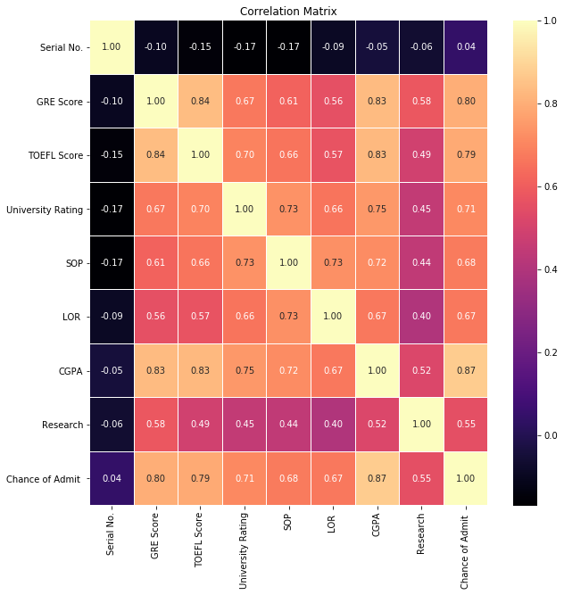

```python
fig, ax = plt.subplots(figsize=(10,10))
sns.heatmap(df.corr(), ax = ax, annot = True, linewidths = 0.05, fmt = '.2f', cmap = 'magma')
plt.title("Correlation Matrix")
plt.show()
```

The correlation matrix shows us all the correlations between the variables. The notable strong correlation variables are:

- TOEFL and GRE Score
- GRE Score and CGPA
- TOEFL and CGPA
- GRE and Chance of Admit
- CGPA and Chance of Admit

Now that we have a better idea of the correlated variables, we will explore these variables in detail to see if multicollinearity exists, or if any variables we need to exclude in our data mining analysis

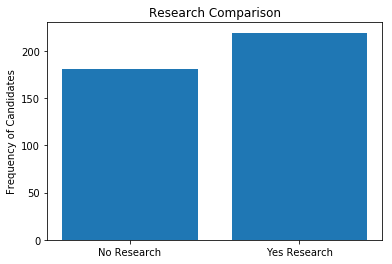

```python
y = np.array([len(df[df.Research == 0]), len(df[df.Research == 1])])
x = ["No Research", "Yes Research"]

plt.bar(x,y)
plt.title("Research Comparison")
plt.ylabel("Frequency of Candidates")
plt.show()
```

Research Comparison Graph shows us that more than half the students in this sample did have research experience, which is an essential part of applying for a Master's degree.

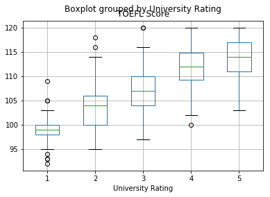

```python
df.boxplot('TOEFL Score', by = 'University Rating')
plt.show()
```

We can see that as the University Rating goes up, the medians and quartile values for TOEFL scores also goes up, meaning that students who score higher on their TOEFL scores generally goes to higher rated universities. There are notable outliers here, but is not significant enough to discharge the relationship.

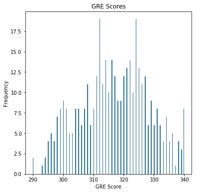

```python
df["GRE Score"].plot(kind = 'hist',bins = 200,figsize = (6,6))
plt.title("GRE Scores")
plt.xlabel("GRE Score")
plt.ylabel("Frequency")
plt.show()
```

GRE Scores are normally distributed, with a density between 310 - 330. Students that score higher than 330 would be a standout for school recruiters.

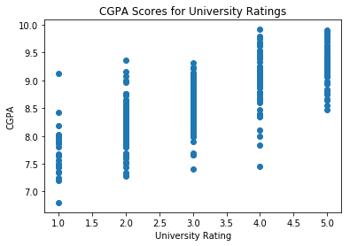

```python
plt.scatter(df["University Rating"],df['CGPA'])
plt.title("CGPA Scores for University Ratings")
plt.xlabel("University Rating")
plt.ylabel("CGPA")
plt.show()
```

We can see that there is a positive relationship exists between CGPA and University Rating. The average CGPA for students with higher University Rating are higher than average CGPA for students with lower University Ratings.

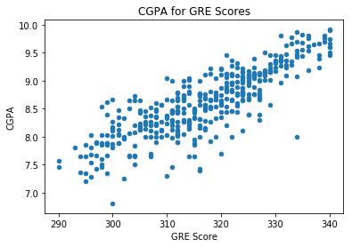

```python
df.plot("GRE Score","CGPA", kind = "scatter")
plt.title("CGPA for GRE Scores")
plt.xlabel("GRE Score")
plt.ylabel("CGPA")
plt.show()
```

There is also a positive linear relation between GRE and CGPA Score, meaning that students that does well in their undergrad studies also scores higher on GRE exam.

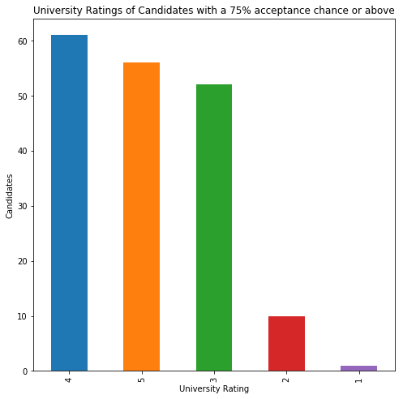

```python
s = df[df["Chance of Admit"] >= 0.75]["University Rating"].value_counts()
plt.title("University Ratings of Candidates with a 75% acceptance chance or above")
s.plot(kind='bar',figsize=(8, 8))
plt.xlabel("University Rating")
plt.ylabel("Candidates")
plt.show()
```

Next, we look at students that has higher acceptance chance, and the threshold we are using is 75%. We can see that candidates that have higher chance of getting into the Master's degree generally have higher university ratings.

### Preparing for Data Mining

Since variable Serial No. is an index and unique key identifier, we will not be using this variable in our analysis. Our predictor variable is Chance of Admit, since we want to know if a student have a good chance of admitting into a Master's degree or not. We would also need to normalize our variables since diSifferent variables are on different scales, so normalizing all the variables to fit into one scale helps us understand our model better.

The model I am building for this particular project is a classification model, meaning that our predictor variable should be binary. Right now, it is not a binary factor, and we need to build a threshold of our choosing in order to split the variable into binary.

I have used 75% for Chance of Admit as my threshold, therefore all samples that has Chance of Admit greater than 0.75 will be given the 1 label and all variables below that threshold will be given a 0 label. This means that when we do our analysis, a label of 1 means that the student will be able to get into the Master's degree, meanwhile 0 means that the student will not.

We will also be using 80/20 for our data partition.

```python
y = df["Chance of Admit"].values
x = df.drop(["Chance of Admit"], axis = 1)

from sklearn.model_selection import train_test_split

x_train, x_test, y_train, y_test = train_test_split(x,y, test_size = 0.20, random_state = 42)

from sklearn.preprocessing import MinMaxScaler
scalerX = MinMaxScaler(feature_range=(0, 1))
x_train[x_train.columns] = scalerX.fit_transform(x_train[x_train.columns])
x_test[x_test.columns] = scalerX.transform(x_test[x_test.columns])

y_train_01 = [1 if each > 0.75 else 0 for each in y_train]
y_test_01  = [1 if each > 0.75 else 0 for each in y_test]

y_train_01 = np.array(y_train_01)
y_test_01 = np.array(y_test_01)
```

### Model 1: Logistic Regression

```python
from sklearn.linear_model import LogisticRegression
from sklearn.metrics import f1_score
from sklearn.metrics import precision_score, recall_score, accuracy_score

lr = LogisticRegression()
lr.fit(x_train,y_train_01)

print("accuracy score: ", accuracy_score(y_test_01, lr.predict(x_test)))
print("precision_score: ", precision_score(y_test_01,lr.predict(x_test)))
print("recall_score: ", recall_score(y_test_01,lr.predict(x_test)))
print("f1_score: ",f1_score(y_test_01,lr.predict(x_test)))
print("score: ", lr.score(x_test,y_test_01))
```

```
accuracy score:  0.8875
precision_score:  0.8108108108108109
recall_score:  0.9375
f1_score:  0.8695652173913043
score:  0.8875
```

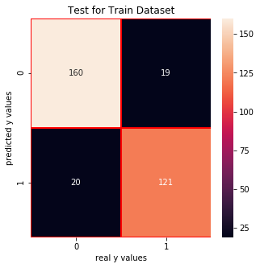

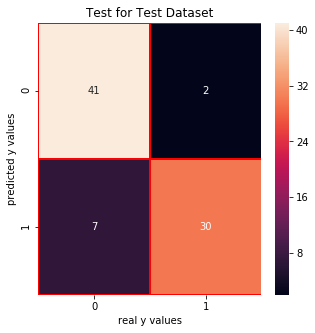

```python
from sklearn.metrics import confusion_matrix
cm_lr = confusion_matrix(lr.predict(x_test),y_test_01)
cm_lr_train = confusion_matrix(lr.predict(x_train), y_train_01)

plt.figure(figsize=(5,5))
sns.heatmap(cm_lr_train, annot = True, linewidths = 0.5, linecolor = "red", fmt = ".0f")
plt.title("Test for Train Dataset")
plt.xlabel("real y values")
plt.ylabel("predicted y values")
plt.show()

plt.figure(figsize=(5,5))
sns.heatmap(cm_lr, annot = True, linewidths = 0.5,linecolor = "red",fmt = ".0f")
plt.title("Test for Test Dataset")
plt.xlabel("real y values")
plt.ylabel("predicted y values")
plt.show()
```

We could see that there are less Type 1 error for our first logistic model, with 2 samples predicted as 0 but are actually 1(False Negative). Meanwhile, there are 7 samples classified with Type 2 error, where the model predicted positive(1) but is actually (0). Even for testing against its training dataset, the logistic regression had 19 type 1 error and 20 type 2 error. Our overall accuracy score for this model is 0.8875, with a F1 score of 0.87 which is acceptable.

### Model 2: Random Forest Classifier

```python
from sklearn.ensemble import RandomForestClassifier
rfc = RandomForestClassifier(n_estimators = 100,random_state = 1)
rfc.fit(x_train,y_train_01)

print("accuracy score: ", accuracy_score(y_test_01, rfc.predict(x_test)))
print("precision_score: ", precision_score(y_test_01,rfc.predict(x_test)))
print("recall_score: ", recall_score(y_test_01,rfc.predict(x_test)))
print("f1_score: ",f1_score(y_test_01,rfc.predict(x_test)))
print("score: ", rfc.score(x_test,y_test_01))
```

```
accuracy score:  0.9375
precision_score:  0.8857142857142857
recall_score:  0.96875
f1_score:  0.9253731343283582
score:  0.9375
```

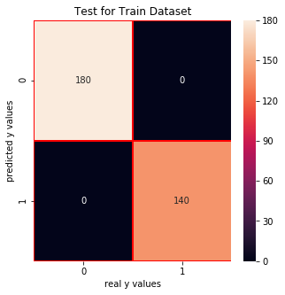

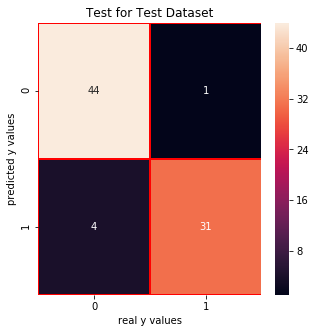

```python
cm_rfc = confusion_matrix(rfc.predict(x_test),y_test_01)
cm_rfc_train = confusion_matrix(rfc.predict(x_train),y_train_01)

plt.figure(figsize=(5,5))
sns.heatmap(cm_rfc_train,annot = True,linewidths=0.5,linecolor="red",fmt = ".0f")
plt.title("Test for Train Dataset")
plt.xlabel("real y values")
plt.ylabel("predicted y values")
plt.show()

plt.figure(figsize=(5,5))
sns.heatmap(cm_rfc,annot = True,linewidths=0.5,linecolor="red",fmt = ".0f")
plt.title("Test for Test Dataset")
plt.xlabel("real y values")
plt.ylabel("predicted y values")
plt.show()
```

The random forest classifier model has a 100% accuracy for test on train dataset. The model shows an improvement from our previous logistic model with notably better scores from the derivations of a normal confusion matrix. There are less Type 1(1) error as well as Type 2(4) error in this model. The accuracy rate is quite high with 0.9375.

### Conclusion

After exploring with the dataset and using two methods of classification regression models, the random forest classifier model proves to perform better at predicting whether a student will get admitted into a Master's degree or not. There were a lot of assumptions made in the dataset as well as in this project, if given more time, we could gather more data after the student got into the Master's degree, since the variable Chance of Admit is a probability variable and not a binary variable. We could also use regression algorithms to predict the probability of Chance of Admit.